# Gasto de los hogares en Salud

Varco María José

## Introducción

El presente informe tiene por objetivo analizar el gasto de los hogares en salud, desde una perspectiva de equidad. Para ello, se analiza la Encuesta Nacional de Gasto de los Hogares (ENGHo) realizada por el Instituto Nacional de Estadísticas y Censos (INDEC) durante el periodo 2017-2018.

El INDEC realiza la Encuesta Nacional de Gastos de los Hogares (ENGHo) con el principal objetivo de obtener información acerca de los gastos y los ingresos de los hogares y sus características sociodemográficas. La encuesta, permite caracterizar las condiciones de vida de los hogares, fundamentalmente en términos de su acceso a los bienes y servicios, y de los ingresos –monetarios o en especie–. Tiene un alcance de 45.000 hogares, ubicados en centros urbanos de 2000 o más habitantes de todo el país.

Las principales variables de la encuesta son el gasto y el ingreso de los hogares. Para el relevamiento de la primera, se registra por cada gasto de consumo realizado por el hogar o uno de sus miembros cada uno de los conceptos relevados. Los valores de las variables monto y cantidad se encuentran transformados para representar valores mensuales para su análisis en términos anuales.

El gasto es registrado según el criterio de lo adquirido durante el periodo de referencia, independientemente del momento en que se cancela o consume el bien en cuestión. En cuanto a ingresos, se releva todo tipo de ingreso de los hogares, incluyendo todas las percepciones cobradas durante el periodo de referencia independientemente del momento en que fueron devengadas.

También se registra información sobre otras variables, como características de las viviendas, características demográficas, educacionales y ocupacionales de sus miembros, y sobre el equipamiento de los hogares, entre otras.

## Exploración de los datos

Los gastos de consumo vinculados a salud se agrupan en la división 6, que puede desagregarse en las siguientes categorías o rubros:

**1. Gasto en medicamentos:** en esta categoría se incluyen una variedad de productos farmacéuticos destinados a tratar distintas patologías, desde medicamentos para la tos y las alergias, hasta medicamentos oncológicos, psiquiátricos o vacunas. También se incluyen elementos para los primeros auxilios y otros productos médicos, tales como, algodón, gasas, vendas, jeringas, etc.

**2. El gasto en consultas** se desagregó en tres grupos:

1. **Gasto en consultas médicas:** se compone de consultas clínicas generales, cardiológicas, gastroenterológicas, ginecológicas y de obstetricia, oftalmológicas, pediátricas, psiquiátricas, de nariz, garganta y oído, y otras consultas médicas.
2. **Gasto en consultas odontológicas:** incluye prótesis dentaria, ortodoncia, obturación, extracción, y otras consultas odontológicas.
3. **Gasto en otras consultas:** abarca consultas al psicólogo, psicopedagogo, fonoaudiólogo, fisioterapeuta, kinesiólogo, estudios médicos, entre otras.

**3. Gasto en internaciones:** el mismo incluye gastos en internaciones, cirugías y partos.

**4. Gasto en dispositivos médicos:** se compone de gasto en anteojos, lentes de contacto, prótesis odontológicas, accesorios ortopédicos, anticonceptivos mecánicos, etc.

**5. Gasto en afiliación:** considera el gasto que realizan los hogares con el objetivo de ampliar la cobertura que poseen, en el caso de los trabajadores formales, adquirir una cobertura adicional o primaría para los miembros del hogar. Incluye 3 categorías de gastos:

1. cuota de afiliación voluntaria a un sistema de salud (prepaga),
2. cuota adicional a la obra social obligatoria,
3. cuota de gasto en emergencias médicas.

La base de datos a utilizar que voy a usar es la unión de la base de gasto de los hogares recortada para las categorias que componen el gasto en salud con la base de los hogares.

```r
gasto_salud_hogares <- read_csv("datos/gasto_salud_hogares.csv")
```

En total la base cuenta con 21543 filas y 141 columnas, donde cada fila corresponde a una unidad de observación, en este caso un hogar o una familia seleccionada para participar en la encuesta.

### Gasto total de los hogares según quintil de ingreso pc del hogar

Antes de analizar el comportamiento del gasto del hogar en un rubro en particular, primero analizo el comportamiento del gasto total del hogar. En particular, se puede ver cuánto gasta en promedio un hogar según el quintil de ingreso pc del hogar. Cabe mencionarl, que el quintil que contiene a los hogares con ingresos más bajos se denomina quintil 1, mientras que el quintil 5 es aquel que contiene a los hogares con mayores ingresos.

```r
gasto_total_hogar <- gasto_salud_hogares |>
    mutate(gasto_total_ponderado = (gastot*pondera)) |>
    group_by(qinpch_t) |>
    summarise(gasto_total_promedio = mean(gasto_total_ponderado, na.rm =TRUE))
```

*Tabla 1: Gasto total promedio de los hogares según quintil de ingresos pc del hogar:*

```r
gasto_total_hogar |>
  knitr::kable(col.names = c("Quintil de ingreso pc del hogar",
                             "Gasto total promedio del hogar"))
```

| Quintil de ingreso pc del hogar | Gasto total promedio del hogar |
| --- | --- |
| 1 | 7485439 |
| 2 | 10757840 |
| 3 | 13552913 |
| 4 | 17225918 |
| 5 | 25059404 |

*Gráficamente:*

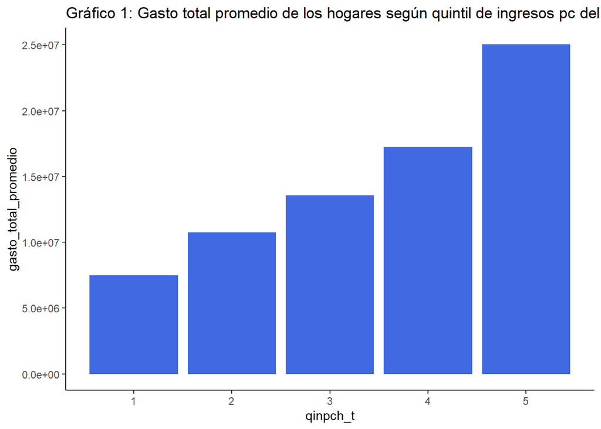

Fuente: Elaboración propia en base a ENGHo 2017-2018, INDEC

```r
gasto_total_hogar |>
ggplot(aes(qinpch_t, gasto_total_promedio)) +
  geom_col(fill="royalblue") +
  labs(title = "Gráfico 1: Gasto total promedio de los hogares según quintil de ingresos pc del hogar") +
  theme_classic()
```

Los resultados muestran que a medida que el hogar se encuentra en un quintil de ingresos pc más alto, el gasto total promedio de ese hogar es mayor.

### Gasto total en salud del hogar según quintil de ingreso per cápita del hogar

A continuación, se puede observar el gasto promedio en salud de los hogares según quintil de ingreso pc del hogar.

```r
gasto_salud_total_hogar <- gasto_salud_hogares |>
    mutate(gtot_salud_ponderado = gc_06*pondera) |>
    group_by(qinpch_t) |>
    summarise(gasto_salud_promedio = mean(gtot_salud_ponderado, na.rm =TRUE))
```

```r
gasto_total_hogar |>
  knitr::kable(col.names = c("Quintil de ingreso pc del hogar",
                             "Gasto total en salud promedio del hogar"))
```

[output not shown]

*Gráficamente:*

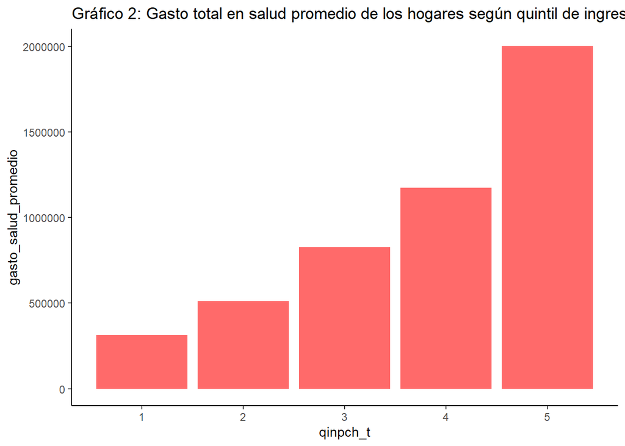

Fuente: Elaboración propia en base a ENGHo 2017-2018, INDEC

```r
gasto_salud_total_hogar |>
ggplot(aes(qinpch_t, gasto_salud_promedio )) +
  geom_col(fill="Indianred1") +
  labs(title = "Gráfico 2: Gasto total en salud promedio de los hogares según quintil de ingresos pc del hogar") +
  theme_classic()
```

Nuevamente, los resultados muestran que a medida que el hogar se encuentra en un quintil de ingresos pc más alto, el gasto total en salud promedio de ese hogar es mayor.

## Hipótesis

### 1) Estructura del gasto en salud del hogar según quintil de ingreso pc del hogar:

```r
estructura_gasto_salud <- gasto_salud_hogares |>
     group_by(qinpch_t) |>
     summarise(gt_med = sum(gasto_medicamentos*pondera, na.rm =TRUE),
               gt_disp = sum(gasto_dispositivos*pondera, na.rm =TRUE),
               gt_consultas_medicas = sum(gasto_consultas_medicas*pondera, na.rm =TRUE),
               gt_consultas_odon= sum(gasto_consultas_odonto*pondera, na.rm =TRUE),
               gt_otrasconsultas= sum(gasto_otrasconsultas*pondera, na.rm =TRUE),
               gt_internaciones= sum(gasto_internaciones*pondera, na.rm =TRUE),
               gt_seguros= sum(gasto_seguros*pondera, na.rm =TRUE),
               gt_salud=sum(gc_06*pondera, na.rm = TRUE),
               g_total=sum(gastot*pondera, na.rm = TRUE),
               y_total=sum(ingtoth*pondera, na.rm = TRUE))
```

```r
estructura_gasto_salud_2 <- estructura_gasto_salud |>
  pivot_longer(cols = c(2:8))
```

```r
estructura_gasto_salud_3 <- estructura_gasto_salud_2 |>
  group_by(qinpch_t) |>
  mutate(participacion = value / sum(value) * 100)
```

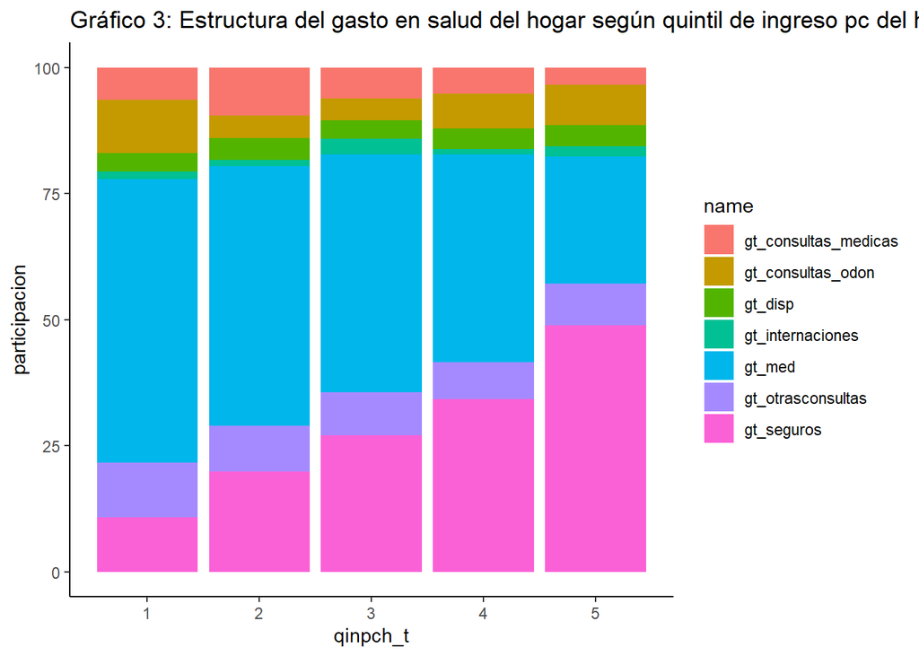

Fuente: Elaboración propia en base a ENGHo 2017-2018, INDEC

```r
estructura_gasto_salud_3 |>
  group_by(qinpch_t) %>%
  ggplot(aes(qinpch_t, participacion, fill = name)) +
  geom_col() +
  labs(title = "Gráfico 3: Estructura del gasto en salud del hogar según quintil de ingreso pc del hogar") +
    theme_classic()
```

Al descomponer el gasto en salud por quintil de ingresos pc del hogar como proporción del gasto total en salud de los hogares, se destacan dos particularidades.

En primer lugar, el gasto en medicamentos (gt_med) es el gasto con mayor participación en el gasto en salud total en los cuatro primeros quintiles de ingreso y el segundo para el quintil de mayores ingresos. Esto muestra la importancia relativa del gasto en medicamentos en los hogares, debido a que el mismo representa en promedio el 44% del gasto en salud.

Segundo, el gasto en afiliación (gt_seguros), el cual incluye la cuota de afiliación voluntaria a un sistema de salud (prepaga), la cuota adicional a la obra social obligatoria y la cuota de gasto en emergencias médicas; tiene menor relevancia en los quintiles de menores ingresos, mientras que en los hogares pertenecientes al quinto quintil es el gasto con mayor participación en el gasto total en salud (50% aproximandamente).

### 2) Participación del gasto total en salud de los hogares según quintil de ingreso pc del hogar en relación al gasto total del hogar y el ingreso total pc del hogar:

En el presente apartado, se puede ver la particupación del gasto total en salud en el gasto total y en el ingreso total de los hogares.

```r
totales <- gasto_salud_hogares |>
     summarise(gt_salud=sum(gc_06*pondera, na.rm = TRUE),
               g_total=sum(gastot*pondera, na.rm = TRUE),
               y_total=sum(ingtoth*pondera, na.rm = TRUE)) |>
     mutate(gt = (gt_salud / g_total) * 100) |>
     mutate(yt = (gt_salud / y_total) * 100)
```

*Tabla 3: Participación del gasto totol en salud del hogar en el gasto total y en ingreso total de los hogares, en porcentaje.*

```r
totales |>
  select(-c(gt_salud, y_total, g_total)) |>
   knitr::kable(col.names = c("Gasto total del hogar",
                             "Ingreso total del hogar"))
```

| Gasto total del hogar | Ingreso total del hogar |
| --- | --- |
| 6.445696 | 4.93946 |

Según la ENGHo, durante el período 2017/2018, los hogares destinaron un 6,4% del gasto total a bienes y servicios de salud. Asimismo, en relación al ingreso, el gasto en salud representó el 4,9%.

```r
estructura_gasto_salud_4 <- estructura_gasto_salud |>
  select(-c(gt_med, gt_disp, gt_consultas_medicas, gt_consultas_odon, gt_otrasconsultas, gt_internaciones, gt_seguros)) |>
  mutate(part_gt = (gt_salud / g_total) * 100) |>
  mutate(part_yt = (gt_salud / y_total) * 100)
```

Luego, se puede descomponer según quintil de ingreso pc del hogar.

*Tabla 3: Participación del gasto totol en salud del hogar en el gasto total y en ingreso total de los hogares según quintil de ingreso pc del hogar, en porcentaje.*

```r
estructura_gasto_salud_5 <- estructura_gasto_salud_4 |>
  select(-c(gt_salud, y_total, g_total))
```

```r
estructura_gasto_salud_5 |>
    knitr::kable(col.names = c("Quintil de ingreso pc del hogar",
                             "Gasto total del hogar",
                             "Ingreso total del hogar"))
```

| Quintil de ingreso pc del hogar | Gasto total del hogar | Ingreso total del hogar |
| --- | --- | --- |
| 1 | 4.185611 | 4.618340 |
| 2 | 4.750799 | 4.194482 |
| 3 | 6.096166 | 4.873093 |
| 4 | 6.815015 | 5.205630 |
| 5 | 7.996548 | 5.137458 |

*Gráficamente:*

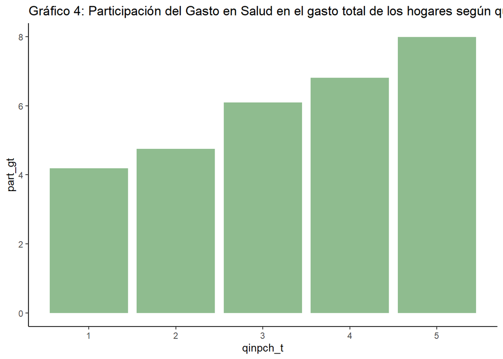

Fuente: Elaboración propia en base a ENGHo 2017-2018, INDEC

```r
estructura_gasto_salud_5 |>
  group_by(qinpch_t) |>
  ggplot(aes(qinpch_t, part_gt)) +
  geom_col(fill="#8FBC8F") +
    labs(title = "Gráfico 4: Participación del Gasto en Salud en el gasto total de los hogares según quintil de ingreso per cápita") +
    theme_classic()
```

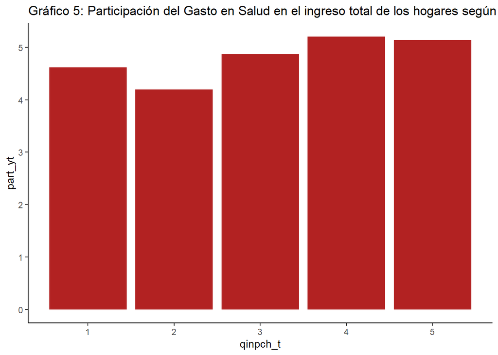

Fuente: Elaboración propia en base a ENGHo 2017-2018, INDEC

```r
estructura_gasto_salud_5 |>
  group_by(qinpch_t) |>
  ggplot(aes(qinpch_t, part_yt)) +
   geom_col(fill="#B22222") +
    labs(title = "Gráfico 5: Participación del Gasto en Salud en el ingreso total de los hogares según quintil de ingreso per cápita") +
    theme_classic()
```

Al analizar el gasto en salud como proporción del gasto total del hogar se puede observar una marcada tendencia creciente en los quintiles (Gráfico N4). Mientras que en el quintil de menores ingresos el gasto en salud sólo representa el 4.2% del gasto total del hogar, en el quintil de mayores el ingreso representa el 8,0% del gasto total. Sin embargo, estas relaciones se modifican si se observa el gasto en salud en relación al ingreso de los hogares. La tendencia creciente que se podía observar en el caso anterior ya no es clara (Gráfico 5). Las diferencias encontradas anteriormente ya no son tan marcadas, existiendo sólo una brecha de medio punto porcentual entre los hogares pertenecientes a los quintiles extremos.

### 3) Gasto de bolsillo en salud de los hogares y en afiliaciones:

El gasto que realizan los hogares vinculado a salud se conforma por:

1. El gasto de bolsillo que son las erogaciones directas por parte de los hogares, incluidos las gratificaciones y los pagos en especie a los médicos y proveedores de fármacos, dispositivos terapéuticos y otros bienes y servicios destinados principalmente a contribuir a la restauración o la mejora del estado de salud de individuos o grupos de población. En este aspecto, el componente que suele tener más peso es el del gasto en medicamentos.
2. Los aportes a seguros privados voluntarios.

El gasto de bolsillo, a diferencia del pago de cuotas en seguros de salud, no es predecible, e implica la exposición a riesgos financieros o a inaccesibilidad a los cuidados de salud necesarios en situaciones de enfermedad.

```r
gasto_de_bolsillo <- gasto_salud_hogares |>
     group_by(qinpch_t) |>
     summarise(gt_med = sum(gasto_medicamentos*pondera, na.rm =TRUE),
               gt_disp = sum(gasto_dispositivos*pondera, na.rm =TRUE),
               gt_consultas_medicas = sum(gasto_consultas_medicas*pondera, na.rm =TRUE),
               gt_consultas_odon= sum(gasto_consultas_odonto*pondera, na.rm =TRUE),
               gt_otrasconsultas= sum(gasto_otrasconsultas*pondera, na.rm =TRUE),
               gt_internaciones= sum(gasto_internaciones*pondera, na.rm =TRUE),
               gt_seguros= sum(gasto_seguros*pondera, na.rm =TRUE),
               gt_salud=sum(gc_06*pondera, na.rm = TRUE),
               g_total=sum(gastot*pondera, na.rm = TRUE),
               y_total=sum(ingtoth*pondera, na.rm = TRUE)) |>
     mutate(gt_bolsillo = gt_med + gt_disp + gt_consultas_medicas + gt_consultas_odon +                 gt_otrasconsultas + gt_internaciones)
```

```r
estructura_gasto_salud_6 <- gasto_de_bolsillo |>
  select(-c(gt_med, gt_disp, gt_consultas_medicas, gt_consultas_odon, gt_otrasconsultas, gt_internaciones)) |>
  mutate(gasto_de_bolsillo = (gt_bolsillo / gt_salud) * 100) |>
  mutate(gasto_en_seguros = (gt_seguros / gt_salud) * 100)
```

```r
estructura_gasto_salud_7 <- estructura_gasto_salud_6 |>
  select(-c(gt_seguros, gt_salud, g_total, y_total, gt_bolsillo)) |>
  pivot_longer(cols = c(2:3))
```

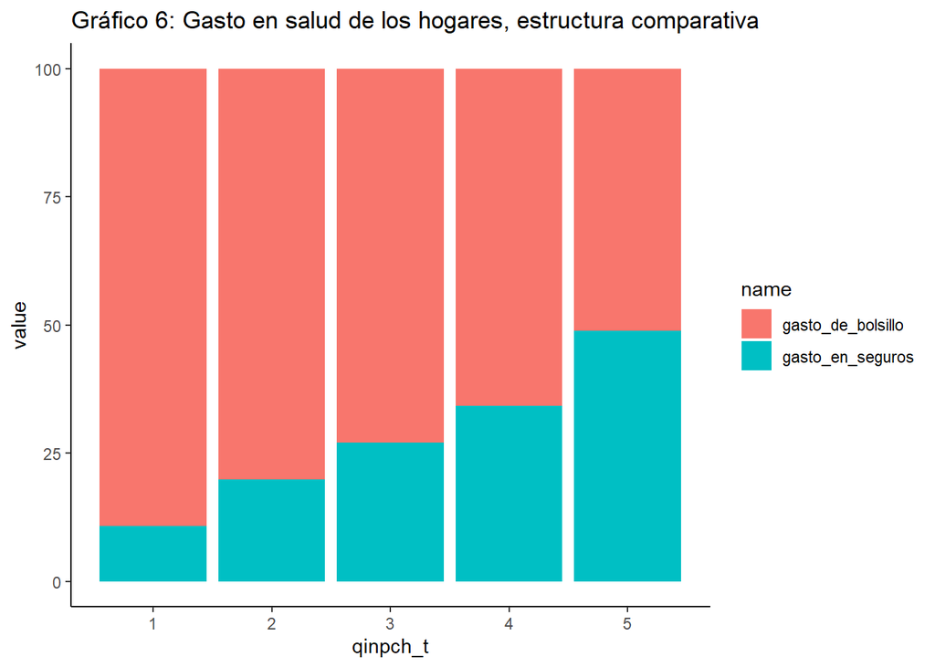

Fuente: Elaboración propia en base a ENGHo 2017-2018, INDEC

```r
estructura_gasto_salud_7 |>
  group_by(qinpch_t) %>%
  ggplot(aes(qinpch_t, value, fill = name)) +
  geom_col() +
  labs(title = "Gráfico 6: Gasto en salud de los hogares, estructura comparativa") +
    theme_classic()
```

La participación del gasto de bolsillo en el gasto total en salud cae, a favor de un aumento de la participación del gasto en afiliacióna a medida que aumenta el quintil de ingreso pc del hogar.